# Appendix

May 03, 2021

### Model Comparison

```r
Model = c("Stepwise Logistic Regression", "Random Forest", "xgboost", "NN LR Terms", "NN RF Terms")
TrainingAUC = c(rst.auc, r.rforest.auc.t, r.xgboost.auc.t, r.nnet.auct, rf.nnet.auct)
ValidAUC = c(rs.auc, r.rforest.auc, r.xgboost.auc, r.nnet.auc, rf.nnet.auc)

FinalFrame = data.frame("Model" = Model, "TrainingAUC"= TrainingAUC, "ValidAUC" = ValidAUC)
knitr:: kable(FinalFrame)
```

| Model | TrainingAUC | ValidAUC |
| --- | --- | --- |
| Stepwise Logistic Regression | 0.639964 | 0.6212 |
| Random Forest | 0.733600 | 0.6185 |
| xgboost | 0.699600 | 0.6087 |
| NN LR Terms | 0.641100 | 0.6246 |
| NN RF Terms | 0.639200 | 0.6249 |

#### Cutoff Analysis

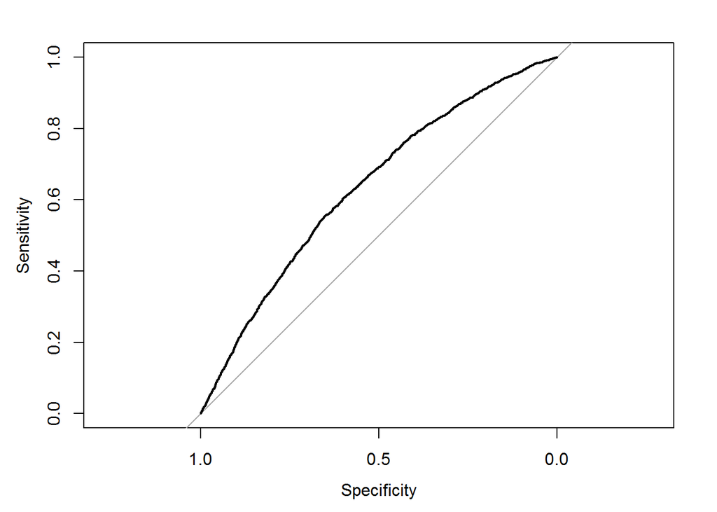

```r
x = predict(nnetRF, newdata = assn, type = "prob")
assn$ProbY = x$Y
rthresh = roc(assn$retained, x[,2])
plot(rthresh)
```

```r
y = coords(rthresh, "best", ret = "threshold")
y$threshold
```

```
## [1] 0.1054152
```

```r
assn$PredY = ifelse(assn$ProbY>=y$threshold, "Y", "N") %>% as.factor()
summary(assn$PredY)
```

```
##     N     Y
## 12970  7613
```

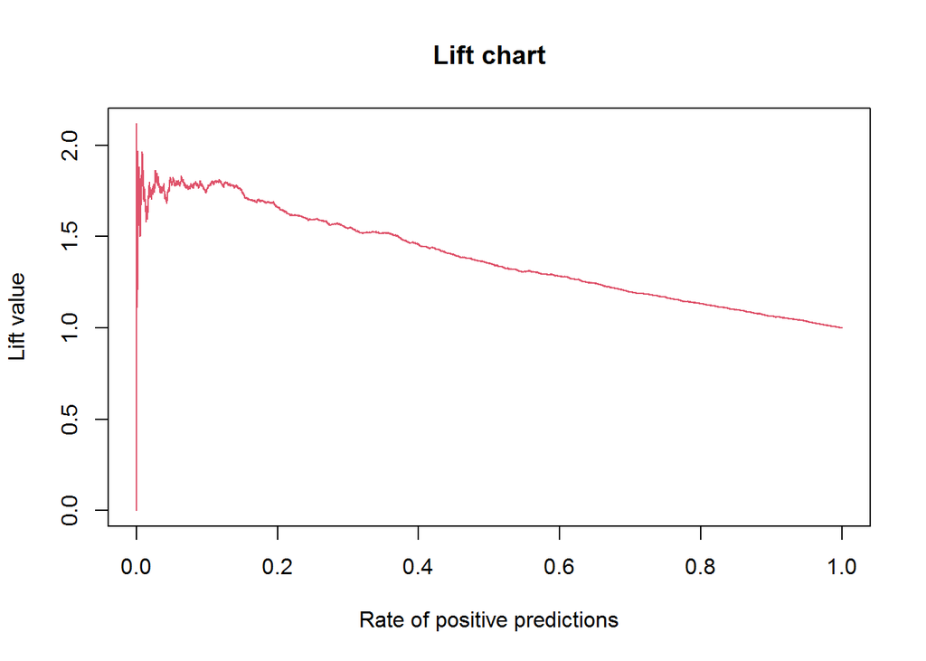

```r
x = predict(nnetRF, newdata = assn, type = "prob")
assn$probY = x$Y
pred = prediction(assn$ProbY, assn$retained)
lift<-performance(pred, "lift", "rpp")
plot(lift, main="Lift chart", col=2)
```

```r
df<-data.frame(lift@y.values,  lift@alpha.values)
colnames(df)<-c("lift", "cutoff")
sub<-subset(df, lift>=1.5)
sub<-sub[order(sub$lift),]
tulip = sub[which.min(sub$cutoff),]
assn$PredYlift = ifelse(assn$ProbY>= tulip$cutoff, "Y", "N") %>% as.factor()

TrueN = subset(assn, assn$retained == "N")
PredN = subset(assn, assn$PredY == "N")
TrueY = subset(assn, assn$retained == "Y")
PredYdf = subset(assn, assn$PredY == "Y")
summary(PredYdf$retained)
```

```
##    N    Y
## 6531 1082
```

```r
CorrectPick = subset(PredYdf, PredYdf$retained=="Y")
```

Correctly identified students who left Miami

```r
nrow(CorrectPick)/nrow(TrueY)
```

```
## [1] 0.5568708
```

We chose to include the best cutoff from the ROC analysis. There has to be, in our view, a balance between sensitivity and specificity. This is due to the fact that the goal is to predict as many students with the potential to leave as possible, however over correcting could lead to many students becoming offended by the targeted measures, fixing a problem they do not have.

### Data Pre-Processing

```r
setwd("~/Desktop/ISA 491/FinalProject")
pacman:: p_load(magrittr, lubridate, tidyverse, forecast, zoo, readxl, DataExplorer, fastDummies)
df = read.csv("domestic_data.csv")
#Only 2012
df = subset(df, df$DateFrom >= 2012) ##maybe 2011, 2011 didn't have farmer

##top 3 majors in each division
df$Division %<>% as.factor()
df$Major%<>%as.factor()
y = levels(df$Division) %>% data.frame()
summary(df$Division)
fin = data.frame()
for(i in 1:(nrow(y)-1)){
  temp = subset(df, df$Division == y$.[i])
  temp = select(temp, "Major")
  temp = summary(temp$Major) %>% data.frame()
  temp= row.names(temp) %>% data.frame()
  temp = temp$.[c(1,2,3)] %>% data.frame()
  fin = rbind(temp, fin)
}
fin = distinct(fin)
for(i in 1:nrow(fin)){
  x = ifelse(df$Major == fin$.[i], 1, 0)
  df$blah = x
  names(df)[ncol(df)] = paste(fin$.[i])
}
y = select(df, 195:ncol(df))
y$Other = ifelse(rowSums(y)==0,1,0) %>%as.factor()
df$Other_Major = y$Other
df[,196:ncol(df)-1] = lapply(df[,196:ncol(df)-1],factor)
summary(df[,196:ncol(df)])
df = select(df, -"American Studies")
df1 = df

##only domestic
df2 = subset(df1, is.na(df$NationDesc))
df3 = subset(df1, df$NationDesc == "United States")
df = rbind(df2,df3)




##impute test scores
ACTScoreList = list()
i = 14
while(i<=36){
  x = subset(df, df$ACTBest == i)
  ACTScoreList[[i]] = x
  i = i+1
}
final = data.frame()
for(i in 14:36){
  MedEng = median(ACTScoreList[[i]]$ACTEng, na.rm = TRUE)
  MedMath = median(ACTScoreList[[i]]$ACTMath, na.rm = TRUE)
  MedRdng = median(ACTScoreList[[i]]$ACTRdng, na.rm = TRUE)
  MedSci = median(ACTScoreList[[i]]$ACTSci, na.rm = TRUE)
  MedWrtng = median(ACTScoreList[[i]]$ACTWRSC, na.rm = TRUE)
  temp = data.frame("Score" = i, "MedEng" = MedEng, "MedMath" = MedMath, "MedRdng" = MedRdng,"MedSci" = MedSci, "MedWrtng" = MedWrtng)
  final = rbind(final, temp)
}
x = data.frame()
for(i in 1:22){
  y= subset(df, df$ACTBest == i+14)
  y$MedEng = final[i,1]
  y$MedMath = final[i,2]
  y$MedRdng = final[i,3]
  y$MedSci = final[i,4]
  y$MedWrtng = final[i,5]
  x = rbind(x,y)
}

x$M_ACT = ifelse(is.na(x$ACTEng), 1, 0) %>%as.factor()
x$ACTEng = ifelse(is.na(x$ACTEng), x$MedEng, x$ACTEng)
x$ACTMath= ifelse(is.na(x$ACTMath), x$MedMath, x$ACTMath)
x$ACTRdng = ifelse(is.na(x$ACTRdng), x$MedRdng, x$ACTRdng)
x$ACTSci = ifelse(is.na(x$ACTSci), x$MedSci, x$ACTSci)
x$ACTWRSC = ifelse(is.na(x$ACTWRSC), x$MedWrtng, x$ACTWRSC)
g = subset(x, !is.na(x$ACTRdng))
g = select(g, -c("MedEng", "MedMath", "MedRdng", "MedSci", "MedWrtng", "SATComp", "SATVerbal", "SATMath", "SATWRSC"))
names(g)
df = g

#only 2018 vars
data2018 = read.csv("domestic_2018.csv")
data2018 = select(data2018, -c("Country", "Column.58", "SummerScholars"))
x = names(data2018)
df1 = df %>% select("DateFrom", matches(x), "retained", 195:ncol(df))


#remove if 100%NA
removecols = data.frame()
keepcols = data.frame()
for(i in 1:ncol(df1)){
  x = sum(is.na(df1[,i]))/nrow(df1)
  if(x>=1){
    print(paste(names(df)[i], "yup"))
    tempr = data.frame("colnum" = i)
    removecols = rbind(removecols, tempr)
  }
  else{
    print(paste(names(df1)[i], "nope"))
    tempk = data.frame("colnum" = i)
    keepcols = rbind(keepcols, tempk)
  }
}
x = removecols$colnum
df1 = select(df1, -x)
df = df1

#take out zip
df= df %>% select(-c("Zipcode", "ZipCode", "Zip5"))


#State level and getting rid of non us residents
dfstate = select(df, c("HomeState", "HighSchoolState"))
x = subset(dfstate, df$HomeState == df$HighSchoolState)
y = subset(dfstate, is.na(df$HighSchoolState))
z = subset(dfstate, df$HomeState != df$HighSchoolState)
df$HomeState = ifelse(is.na(df$HomeState), df$HighSchoolState, df$HomeState)
#df$M_HighDifHome = ifelse(df$HomeState != df$HighSchoolState, 1, 0) #have or not?
df$HomeState %<>%as.factor()
df = subset(df, !is.na(df$HomeState))
df = select(df, -"HighSchoolState")

##home state dummify
homestate = select(df, "HomeState")
homestate$HomeState %<>% as.factor()
summary(homestate$HomeState)
homestate$HomeState_OH = ifelse(homestate$HomeState =="OH",1,0)
homestate$HomeState_IL = ifelse(homestate$HomeState =="IL",1,0)
homestate$HomeState_MI = ifelse(homestate$HomeState =="MI",1,0)
homestate$HomeState_Other = ifelse(rowSums(homestate[,c(2,3,4)])==0,1,0)
homestate = select(homestate, -"HomeState")
homestate[1:4] = lapply(homestate[,1:4], factor)
df = cbind(df, homestate)
df = select(df, -"HomeState")



##first gen get rid of 85pct na?
#x = subset(df, is.na(df$FirstGen))
df$FirstGen %<>% as.factor()
summary(df$FirstGen)
df$FirstGen = ifelse(is.na(df$FirstGen) | df$FirstGen == "", 0, 1) %>% as.factor()
summary(df$FirstGen)

##Alum connect
df$AlumniConnection %<>%as.factor()
summary(df$AlumniConnection)
df$AlumniConnection = ifelse(is.na(df$AlumniConnection)|df$AlumniConnection =="",0, 1) %>% as.factor()
summary(df$AlumniConnection)
# Alum = select(df, "AlumniConnection")
# Alum$Alumcheck = ifelse(is.na(df$AlumniConnection)|df$AlumniConnection =="",0, 1)



##Race, add dummy for white dummy for top 2
#decide years before doing more here
sum(is.na(df$FullRace))
df$FullRace = ifelse(df$FullRace == "White" |is.na(df$FullRace), "WH", df$FullRace)
df$White = ifelse(df$FullRace=="WH",1,0) %>% as.factor()
df$OtherRace = ifelse(df$White==1,0,1)%>% as.factor()
summary(df$White)
summary(df$OtherRace)
names(df)
df = select(df, -c("FullRace","AS_Race", "AI_Race", "BL_Race" , "HS_Race", "PI_Race", "WH_Race", "Hispanic", "OneRace", "FullRace", "AlmostFullRace"))


##apply type
df$ApplicationType %<>% as.factor()
summary(df$ApplicationType) %>% data.frame() ->t
t = paste0("AppType_",rownames(t)) %>% data.frame()
df = subset(df, df$InternationalFlag == "Domestic"|df$InternationalFlag=="domestic") #now only domestic
x = dummy_cols(.data = df$ApplicationType)
names(x)[2:ncol(x)]= t$.
x = select(x, -".data")
x$AppType_OE %<>% as.factor()
x$AppType_OF %<>% as.factor()
x$AppType_OI%<>% as.factor()
x$AppType_OM%<>% as.factor()
x = select(x, -"AppType_OI")
summary(x)
df = cbind(df, x)
df = select(df, -"ApplicationType")
#EER
df1 = df
summary(as.factor(df$EER))
df$EER = ifelse(df$EER=="2A---", "2A", df$EER)
df$EER = ifelse(df$EER=="3A---", "3A", df$EER)
df$EER = ifelse(df$EER=="4A---", "4A", df$EER)
df$EER = ifelse(df$EER=="2---", "2", df$EER)
df$EER = ifelse(df$EER=="3---", "3", df$EER)
df$EER = ifelse(df$EER=="4---", "4", df$EER)
summary(as.factor(df$EER))
x = dummy_cols(df$EER)
summary(x)
x = select(x, c(".data_2", ".data_2A", ".data_3", ".data_3A", ".data_4", ".data_4A"))
y =summary(as.factor(df$EER)) %>%data.frame()
y
z = paste0("EER_",rownames(y)) %>%data.frame()
a = z[c(6,5,2,1,3,4),] %>%data.frame()
names(x)[1:ncol(x)] = a[1:6,]
x$EER_Other = ifelse(rowSums(x[,1:6])==0, 1,0) %>%as.factor
x[,1:6] = lapply(x[,1:6], factor)
df = cbind(df, x)
df = select(df, -"EER")
```

```r
#getting rid of toeffel
df1 = df
names(df)
toeffl = names(df[,63:66])
df = select(df, -toeffl)
names(df)
##collapse eer, do something with class size, bridges
sum(is.na(df$ClassSize))/nrow(df)
classsize = select(df, c("DateFrom", "ClassSize"))
df$M_ClassSize = ifelse(is.na(df$ClassSize),1,0)%>% as.factor()
df$ClassSize = ifelse(is.na(df$ClassSize), mean(df$ClassSize, na.rm=TRUE), df$ClassSize)

#bridges
bridges = select(df, "Bridges")
bridges$Bridges %<>%as.factor()
summary(bridges$Bridges)
bridges$Bridges = ifelse(bridges$Bridges!="Y"|is.na(bridges$Bridges),0,1) %>%as.factor()
summary(bridges$Bridges)
df$Bridges = bridges$Bridges
summary(df$Bridges)

#State residency
stateres = select(df, "StateResidency")
stateres$StateResidency %<>% as.factor()
df$StateResidency = ifelse(df$StateResidency == "R",1,0) %>% as.factor()
summary(df$StateResidency)


#Gender
df$Gender = ifelse(df$Gender == "M",1,0)
df$Gender %<>% as.factor()
summary(df$Gender)

#special consideration
specialcons = select(df, "Special.Consideration")
specialcons$Special.Consideration %<>% as.factor()
summary(specialcons$Special.Consideration)
specialcons$Specials = ifelse(is.na(specialcons$Special.Consideration)|specialcons$Special.Consideration =="", 0, 1)
df$Special.Consideration = ifelse(is.na(df$Special.Consideration)|df$Special.Consideration =="",0,1)
df$Special.Consideration %<>% as.factor()
summary(df$Special.Consideration)


#housing
Live = select(df, "Housing")
Live$Housing %<>% as.factor()
summary(Live$Housing)
Live$Housing_OnCampus = ifelse(Live$Housing == "On Campus",1,0)
Live$Housing_OnCampus = ifelse(is.na(Live$Housing),0,Live$Housing_OnCampus) %>%as.factor()
summary(Live$Housing_OnCampus)
Live = select(Live, "Housing_OnCampus")
df$Housing_OnCampus = Live$Housing_OnCampus
df = select(df, -"Housing")
##drop aceflag, county
Ace = select(df, "ACEFlag")
Ace$ACEFlag %<>% as.factor()
summary(Ace$ACEFlag)
df = select(df, -"ACEFlag")


#status
df$Status %<>% as.factor()
summary(df$Status)


##getting rid of BS
names(df)
df = select(df, -c("tag","Division", "Concentration", "DisciplinaryQuestion1", "CountyDesc","SuppMajor1","Major", "Parent.2.Educational.Level", "Decision", "SuppMajor2", "SuppMajor3", "ApplicationDate", "ApplicationDate_Formatted" ,"MCFlag", "Status", "InternationalFlag", "DecisionDate", "DecisionType", "DecisionDate_Formatted", "DecisionDateFormatted", "OriginalGPA", "GPAScale", "RoundedGPA", "MeritGPAThresholdFlag", "MeritGPA", "GPAOrig", "ClassRank", "ACTComposite", "ACTMaxComposite", "ACTChoice","ACTChoice", "ACTMaxEnglish", "ACTMaxMath", "ACTMaxReading", "ACTMaxSciReasoning", "ACTWritingMax", "SAT.R.ERW", "SAT.R.Math", "HighSchoolCode", "Citizen", "Citizenship", "Citizenship2", "Race", "FullEthn.Race"))


##
df$Parent.1.Education.Level
df.drop = select(df, "Parent.1.Education.Level")
df.drop$Parent.1.Education.Level = ifelse(is.na(df.drop$Parent.1.Education.Level), "Other", df.drop$Parent.1.Education.Level) %>%as.factor()
df.drop$Parent.1.Education.Level <- factor(df.drop$Parent.1.Education.Level)
summary(df.drop$Parent.1.Education.Level)
levels(df.drop$Parent.1.Education.Level) <- list("Graduated from college/university" = c("Graduated from college/university"),
                                                 "Graduate school" = c("Graduate school"),
                                                 "Some college/university" = c("Some college/university"),
                                                 "Graduated from high/secondary school (or equivalent)" = c("Graduated from high/secondary school (or equivalent)"),
                                                 "Other" = c("Completed grade/primary school", "Graduated trade school", "None","Some grade/primary school", "Some high/secondary school", "Some trade school"))
summary(df.drop)
df.drop$ParEduUni = ifelse(df.drop$Parent.1.Education.Level == "Graduated from college/university",1,0) %>% as.factor()
df.drop$ParEduGrad = ifelse(df.drop$Parent.1.Education.Level == "Graduate school",1,0) %>%as.factor()
df.drop$ParEduSomeUni = ifelse(df.drop$Parent.1.Education.Level == "Some college/university",1,0) %>% as.factor()
df.drop$ParEduHS = ifelse(df.drop$Parent.1.Education.Level == "Graduated from high/secondary school (or equivalent)",1,0) %>% as.factor()
df.drop$ParEduOther = ifelse(df.drop$Parent.1.Education.Level ==  "Other",1,0) %>% as.factor()
df.drop = select(df.drop, -1)
df = cbind(df, df.drop)
df = select(df, -"Parent.1.Education.Level")

#Miami Ranks
ranks = select(df, "MiamiRanks")
ranks$MiamiRanks = ifelse(is.na(ranks$MiamiRanks),"", ranks$MiamiRanks)
ranks$MiamiRanks %<>% as.factor()
summary(ranks$MiamiRanks)
ranks$MiamiRanks_1 = ifelse(ranks$MiamiRanks == 1,1,0)%>% as.factor()
ranks$MiamiRanks_NoFAFSA = ifelse(ranks$MiamiRanks == "noFAFSA",1,0)%>% as.factor()
ranks$MiamiRanks_2 = ifelse(ranks$MiamiRanks == 2,1,0)%>% as.factor()
ranks$MiamiRanks_Other = ifelse(rowSums(df[,2:4]==0),1,0)%>% as.factor()
summary(ranks)
ranks = select(ranks, 2:5)
df = cbind(df, ranks)
df = select(df, -"MiamiRanks")

#FINAL SHIT
plot_missing(df)
summary(as.factor(df$AcadRS))
df %<>% na.omit()
plot_bar(df)
plot_histogram(df)
#df = select(df, -"DateFrom")
df$retained %<>% as.factor()
summary(df$retained)
df$retained = ifelse(df$retained == 1,0,1) %>%as.factor()
summary(df$retained)
summary(df)

write_rds(df, "YooLauxFinalData.rds")
df = read_rds("YooLauxFinalData.rds")
```

#### Remove Variables

We choose to remove all variables that were used for international students, variables not contained in the 2018 data, personal information about the student (name, address, phone, etc.), and ID variables. We found these variables were not useful in predicting the retention of a domestic first year student in 2018.

#### Imputation

We choose to impute test scores. We did this because there was less than 50% missing within some test score variables, making it beneficial for use to impute the missing values. We did this by getting the median score for each of the subtests (math, science, reading, and english) by the aggregate score. A person who took the SAT, or any other test, would have their subtest score imputed based on their ACT equivalent score.

#### Split to Training/Validation

We tried many different methods for subsetting into training and validation. In the end, randomly partitioning the data worked the best. For example, it is possible that training on certain years introduces unseen bias into the models.

### Modeling

#### StepWise Logistic Regression

```r
set.seed(42)
ctrl<-trainControl(method="none", summaryFunction = twoClassSummary, classProbs = TRUE, savePredictions = TRUE)
lrstep<-train(retained~., data=training, method="glmStepAIC", direction="both", metric="ROC", trControl=ctrl, trace=0)
summary(lrstep)
```

```
##
## Call:
## NULL
##
## Deviance Residuals:
##     Min       1Q   Median       3Q      Max
## -1.0418  -0.4794  -0.4093  -0.3414   2.9652
##
## Coefficients:
##                     Estimate Std. Error z value Pr(>|z|)
## (Intercept)        1.2450200  0.3106750   4.007 6.14e-05 ***
## FirstGen1          0.3105556  0.0813949   3.815 0.000136 ***
## AlumniConnection1 -0.2698726  0.0651036  -4.145 3.39e-05 ***
## GPA               -0.5500969  0.0812076  -6.774 1.25e-11 ***
## AcadRS            -0.0169467  0.0077851  -2.177 0.029495 *
## ClassSize         -0.0002656  0.0001755  -1.514 0.130119
## ACTMath           -0.0304519  0.0091278  -3.336 0.000849 ***
## Bridges1          -0.3889778  0.1406242  -2.766 0.005673 **
## HomeState_IL1     -0.2693421  0.1044146  -2.580 0.009893 **
## HomeState_MI1     -0.4078387  0.1860657  -2.192 0.028386 *
## AppType_OE1       -0.4566355  0.1016889  -4.491 7.11e-06 ***
## AppType_OF1       -0.2811666  0.0832768  -3.376 0.000735 ***
## EER_21             0.3309853  0.1681448   1.968 0.049016 *
## EER_2A1            0.3598393  0.1233643   2.917 0.003535 **
## EER_31             0.2462748  0.0915514   2.690 0.007145 **
## EER_3A1            0.1081080  0.0734959   1.471 0.141307
## Housing_OnCampus1 -0.1612305  0.0702980  -2.294 0.021818 *
## ---
## Signif. codes:  0 '***' 0.001 '**' 0.01 '*' 0.05 '.' 0.1 ' ' 1
##
## (Dispersion parameter for binomial family taken to be 1)
##
##     Null deviance: 9012.1  on 14408  degrees of freedom
## Residual deviance: 8733.0  on 14392  degrees of freedom
## AIC: 8767
##
## Number of Fisher Scoring iterations: 5
```

#### Random Forest

```r
cvindx<-createFolds(trainIndex, k=10, returnTrain = TRUE)

ctrl <- trainControl(method="cv", index=cvindx, summaryFunction = twoClassSummary, classProbs = TRUE)

library(caret)
library(ranger)

tunegrid <- expand.grid(
  .mtry = c(5, 10, 15, 20, 25, 30, 35),
  .splitrule = c("gini", "engropy"),
  .min.node.size = c(250, 500)
)


library(doParallel)
detectCores()
cl <- makePSOCKcluster(8) #starts the cluster
registerDoParallel(cl)


rforest<-train(retained~., data=training, method="ranger", tuneGrid=tunegrid, metric="ROC",
               num.trees=1000, importance="impurity", trControl=ctrl )
varImp(rforest)

stopCluster(cl)
```

Increased trees to 1000 and increased min node size vs. in class. Min node size took some trial and error but this was the best option, figured it had to be bigger given larger dataset.

```
## ranger variable importance
##
##   only 20 most important variables shown (out of 44)
##
##                   Overall
## GPA               100.000
## AcadRS             50.293
## ClassSize          38.566
## ACTMath            32.832
## ACTEng             31.901
## ACTBest            29.923
## ACTSci             24.625
## ACTRdng            23.805
## ACTWRSC            19.358
## AppType_OM1        16.073
## AlumniConnection1  13.110
## FirstGen1          10.765
## EER_2A1             7.578
## MiamiRanks_Other1   5.464
## EER_41              3.587
## ParEduHS1           3.399
## AppType_OF1         3.000
## Gender1             2.871
## AppType_OE1         2.850
## ParEduUni1          2.231
```

#### xgboost

```r
library(xgboost)
Grid <-  expand.grid(nrounds = 100,
                     max_depth = c(3,6),
                     eta = c(0.001,0.1),
                     gamma = c(0.5, 0.75),
                     colsample_bytree = c(0.3, 1),
                     min_child_weight = c(0,15),
                     subsample = c(0.3,1)
)
cl <- makePSOCKcluster(8) #starts the cluster
registerDoParallel(cl)

xgboost <- train(retained~.,
                 data = training,
                 method = "xgbTree",
                 trControl=ctrl,
                 tuneGrid=Grid,
                 metric='ROC')

stopCluster(cl)
xgboost
```

Just changed the max depth given more vars and bigger dataset. Worked around changing gini a bit but nothing we did improved the model vs. defaults in class.

[output not shown]

[output cut: 92 more lines]

[output not shown]

#### Neural Network with Linear Terms

```r
termsLR = names(lrstep$finalModel$coefficients)[-1]
termsLR = gsub("1","",termsLR)

set.seed(42)

cvindx<-createFolds(trainIndex, k=10, returnTrain = TRUE)
ctrl <- trainControl(method="cv", index=cvindx, summaryFunction = twoClassSummary, classProbs = TRUE)

tunegrid<-expand.grid( .size=1:10, .decay= c(0, 0.1, 0.5 ,1))
maxSize<-max(tunegrid$.size)

numWts<-(length(termLR) *10) +10 +10+1


library(doParallel)

cl <- makePSOCKcluster(8) #Starts the parallel computing
registerDoParallel(cl)

nnetLR<-train(x=training[,termsLR], y=training$retained,
               method="nnet",
               metric="ROC",
               linout=FALSE,
               preProcess = c("range"),
               tuneGrid = tunegrid,

               trace=FALSE,
               maxit=100,
               MaxNWts=numWts,
               trControl=ctrl)


stopCluster(cl)
nnetLR
```

Changed the max weights but kept most things similar.

```
## Neural Network
##
## 14409 samples
##    16 predictor
##     2 classes: 'N', 'Y'
##
## Pre-processing: re-scaling to [0, 1] (4), ignore (12)
## Resampling: Cross-Validated (10 fold)
## Summary of sample sizes: 12967, 12968, 12968, 12969, 12968, 12968, ...
## Resampling results across tuning parameters:
##
##   size  decay  ROC        Sens       Spec
##    1    0.0    0.6039761  1.0000000  0.0000000000
##    1    0.1    0.6365631  1.0000000  0.0000000000
##    1    0.5    0.6355455  1.0000000  0.0000000000
```

[output cut: 40 more lines]

#### Neural Network with Random Forest Terms

```r
termsRF = varImp(rforest)
termsRF = rownames(termsRF$importance)[1:25]
termsRF = gsub("1", "", termsRF)
cvindx<-createFolds(trainIndex, k=10, returnTrain = TRUE)
ctrl <- trainControl(method="cv", index=cvindx, summaryFunction = twoClassSummary, classProbs = TRUE)

tunegrid<-expand.grid( .size=1:10, .decay= c(0, 0.1, 0.5 ,1))
maxSize<-max(tunegrid$.size)

numWts<-500


library(doParallel)

cl <- makePSOCKcluster(8) #Starts the parallel computing
registerDoParallel(cl)

nnetRF<-train(x=training[,termsRF], y=training$retained,
              method="nnet",
              metric="ROC",
              linout=FALSE,
              preProcess = c("range"),
              tuneGrid = tunegrid,

              trace=FALSE,
              maxit=100,
              MaxNWts=numWts,
              trControl=ctrl)


stopCluster(cl)
nnetRF
```

```r
nnetRF
```

```
## Neural Network
##
## 14409 samples
##    25 predictor
##     2 classes: 'N', 'Y'
##
## Pre-processing: re-scaling to [0, 1] (9), ignore (16)
## Resampling: Cross-Validated (10 fold)
## Summary of sample sizes: 12969, 12967, 12968, 12966, 12968, 12968, ...
## Resampling results across tuning parameters:
##
##   size  decay  ROC        Sens       Spec
##    1    0.0    0.5875686  1.0000000  0.0000000000
##    1    0.1    0.6274342  1.0000000  0.0000000000
##    1    0.5    0.6269441  1.0000000  0.0000000000
```

[output cut: 40 more lines]

#### Why We Chose NNetRF and the Profile

```r
#Neural Net with RF terms
p.nnet<-predict(nnetRF, data=training, type="prob")
r<-roc(training$retained,  p.nnet[,2])
rf.nnet.auct<-round(r$auc,4)

## Area under the curve:
p.nnet<-predict(nnetRF, newdata=valid, type="prob")
r<-roc(valid$retained,  p.nnet[,2])
rf.nnet.auc<-round(r$auc,4)
varImp(nnetRF)
```

```
## nnet variable importance
##
##   only 20 most important variables shown (out of 25)
##
##                  Overall
## GPA              100.000
## AppType_OM        23.127
## ACTBest           20.941
## AcadRS            20.237
## White             17.458
## OtherRace         17.268
## HomeState_OH      15.547
## ClassSize         13.994
## ACTMath           13.379
## Bridges           13.073
## FirstGen          12.997
## HomeState_Other   12.668
## AlumniConnection   9.621
## AppType_OF         9.089
## ACTRdng            4.232
## HomeState_IL       3.483
## Gender             3.324
## StateResidency     2.908
## ACTEng             2.674
## HomeState_MI       2.224
```

```r
summary(nnetRF$finalModel)
```

```
## a 25-1-1 network with 28 weights
## options were - entropy fitting  decay=0.1
##   b->h1  i1->h1  i2->h1  i3->h1  i4->h1  i5->h1  i6->h1  i7->h1  i8->h1  i9->h1
##   -1.79    0.17   -0.19   -0.68    0.51    0.07    1.08    5.07    1.04    0.73
## i10->h1 i11->h1 i12->h1 i13->h1 i14->h1 i15->h1 i16->h1 i17->h1 i18->h1 i19->h1
##    0.16    0.70   -0.23    0.12   -0.08    0.68    0.02   -0.80   -0.20   -0.13
## i20->h1 i21->h1 i22->h1 i23->h1 i24->h1 i25->h1
##   -0.66   -0.90   -0.89   -0.13   -0.48   -1.19
##  b->o h1->o
## -1.21 -2.91
```

The Neural Net using our Random Forest terms resulted in the model with the highest validation AUC as well as the lowest difference between the training and validation AUC. It provided some very nice insight into which variables were important in whether a student is retained or not. Unfortunately, being a neural net, it required us to think intuitvely and look at predicted values of some samples to determine whether a variable helped or hurt the chances of a student being retained.